# Divvy Bike Sharing: Ride Behavior Analysis of Members vs. Casual Users (2019–2020)

Ashna Britto

2025-07-16

## Introduction

This case study analyzes user behavior within the Divvy bike-sharing system in Chicago, focusing on a comparison between members and casual users. Using data from the first quarters of 2019 and 2020, we examine ride duration patterns, day-of-week trends, and key differences between user types. The goal is to derive actionable insights for business decisions such as marketing strategy, membership retention, and operational efficiency.

## Data Collection

```r
library(tidyverse)
library(lubridate)
library(readr)
library(conflicted)
conflict_prefer("filter", "dplyr")
```

```
## [conflicted] Will prefer dplyr::filter over any other package.
```

```r
conflict_prefer("lag", "dplyr")
```

```
## [conflicted] Will prefer dplyr::lag over any other package.
```

```r
q1_2019 <- read_csv("Divvy_Trips_2019_Q1.csv")
```

```
## ──────────────────────────────────────────────────────── Delimiter: "," chr
## (6): start_time, end_time, from_station_name, to_station_name, usertype... dbl
## (6): trip_id, day_of_week, bikeid, from_station_id, to_station_id, birt... num
## (1): tripduration lgl (4): ...15, ...16, ...17, ...18 time (1): ride_length
```

```r
q1_2020 <- read_csv("Divvy_Trips_2020_Q1.csv")
```

# Rename 2019 columns to match 2020 format

```r
q1_2019 <- rename(q1_2019,
                  ride_id = trip_id,
                  rideable_type = bikeid,
                  started_at = start_time,
                  ended_at = end_time,
                  start_station_name = from_station_name,
                  start_station_id = from_station_id,
                  end_station_name = to_station_name,
                  end_station_id = to_station_id,
                  member_casual = usertype)
```

# Ensure types match

```r
q1_2019 <- mutate(q1_2019,
                  ride_id = as.character(ride_id),
                  rideable_type = as.character(rideable_type))
```

# Combine data

```r
all_trips <- bind_rows(q1_2019, q1_2020)
```

# Drop unnecessary columns

```r
all_trips <- all_trips %>%
  select(-c(start_lat, start_lng, end_lat, end_lng, birthyear, gender, tripduration))
```

# Normalize user type labels

```r
all_trips <- all_trips %>%
  mutate(member_casual = recode(member_casual,
                                "Subscriber" = "member",
                                "Customer" = "casual"))
```

# Add date-related columns

```r
all_trips <- all_trips %>%
  mutate(date = as.Date(started_at),
         month = format(date, "%m"),
         day = format(date, "%d"),
         year = format(date, "%Y"),
         day_of_week = format(date, "%A"),
         ride_length = as.numeric(difftime(ended_at, started_at, units = "secs")))
```

# Remove invalid data

```r
all_trips_v2 <- all_trips %>%
  filter(start_station_name != "HQ QR" & ride_length > 0)
```

## Descriptive Analysis

```r
summary(all_trips_v2$ride_length)
```

```
##     Min.  1st Qu.   Median     Mean  3rd Qu.     Max.
##        1      331      539     1190      912 10632022
```

```r
aggregate(ride_length ~ member_casual, data = all_trips_v2, FUN = mean)
```

```
##   member_casual ride_length
## 1        casual   5372.7839
## 2        member    795.2523
```

```r
aggregate(ride_length ~ member_casual, data = all_trips_v2, FUN = median)
```

```
##   member_casual ride_length
## 1        casual        1393
## 2        member         508
```

```r
aggregate(ride_length ~ member_casual + day_of_week, data = all_trips_v2, FUN = mean)
```

```
##    member_casual day_of_week ride_length
## 1         casual      Friday   6090.7373
## 2         member      Friday    796.7338
## 3         casual      Monday   4752.0504
## 4         member      Monday    822.3112
## 5         casual    Saturday   4950.7708
## 6         member    Saturday    974.0730
## 7         casual      Sunday   5061.3044
## 8         member      Sunday    972.9383
## 9         casual    Thursday   8451.6669
## 10        member    Thursday    707.2093
## 11        casual     Tuesday   4561.8039
## 12        member     Tuesday    769.4416
## 13        casual   Wednesday   4480.3724
## 14        member   Wednesday    711.9838
```

## Visualizations

```r
library(ggplot2)
library(lubridate)
```

# Rides per weekday by user type

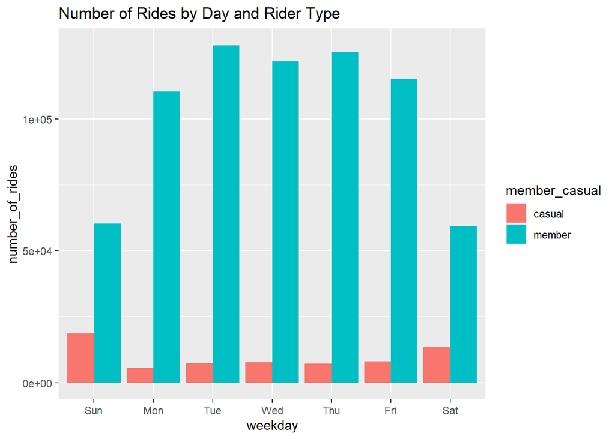

```r
all_trips_v2 %>%
  mutate(weekday = wday(started_at, label = TRUE)) %>%
  group_by(member_casual, weekday) %>%
  summarise(number_of_rides = n(), average_duration = mean(ride_length)) %>%
  ggplot(aes(x = weekday, y = number_of_rides, fill = member_casual)) +
  geom_col(position = "dodge") +
  labs(title = "Number of Rides by Day and Rider Type")
```

# Average duration by weekday and user type

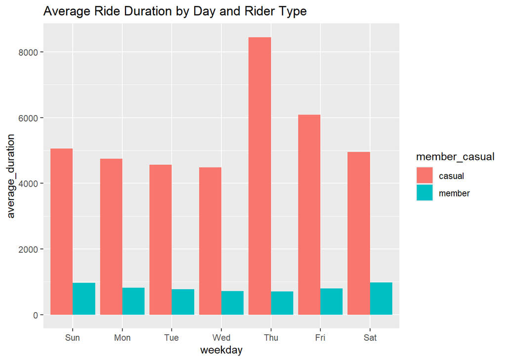

```r
all_trips_v2 %>%
  mutate(weekday = wday(started_at, label = TRUE)) %>%
  group_by(member_casual, weekday) %>%
  summarise(number_of_rides = n(), average_duration = mean(ride_length)) %>%
  ggplot(aes(x = weekday, y = average_duration, fill = member_casual)) +
  geom_col(position = "dodge") +
  labs(title = "Average Ride Duration by Day and Rider Type")
```

## Insights & Recommendations

Members take shorter, more frequent rides, especially on weekdays, likely for commuting.

Marketing could target casual users with weekend promotions or encourage them to become members.

Operational resources (bike availability) should be balanced accordingly across weekdays and weekends.

## Conclusion

This analysis highlights distinct ride behaviors between Divvy members and casual users. Members ride more frequently for shorter durations, while casual users ride less often but for longer durations. Understanding these patterns enables better marketing, pricing strategies, and service planning. The use of R for wrangling, cleaning, and visualizing this data demonstrates how open-source tools can power real-world business intelligence.